# Data Translation Assignment

Kyle Bailey, Ryan Cowles, Joshua Jayandran, Samuel Suk, George Thiss, and Octavian Tofoleanu

03/18/2022

# Introduction

- We saw a sharp jump discontinuity in April of 2020 with a nearly 9% increase in unemployment following our defined start of Covid.
- Our regression analyses primarily focused on the variables we felt would impact unemployment like employment sector, region, education level, and race.

# Methodology - Regression Discontinuity

Assumptions: - Our first assumption is necessary as a prerequisite for RD models, that the error term does not jump to the point of discontinuity. In this case, we’re assuming no other variable besides Covid is explaining the dramatic effect on the unemployment rate at the cutoff. - According to the CDC, March 15th was when states began implementing lockdowns in the US, which would correlate with the 15th month in our data set; however, we use April (16th month) as the cut off month for our time based running variable because we want to account for the lag effect of policy on the labor economy. - We’re assuming individuals in April who lost their job, and thereby contribute to the unemployment rate, did not do so through self-selection or any form of manipulation because the incentive to lose one’s job is minimal as it means sacrificing earnings. Besides a person’s industry, geography, education, and race, we’re assuming no outlying difference among individuals around the cutoff.

# Graph of Unemployment Rate and Date Across all Industries 2017 and 2018:

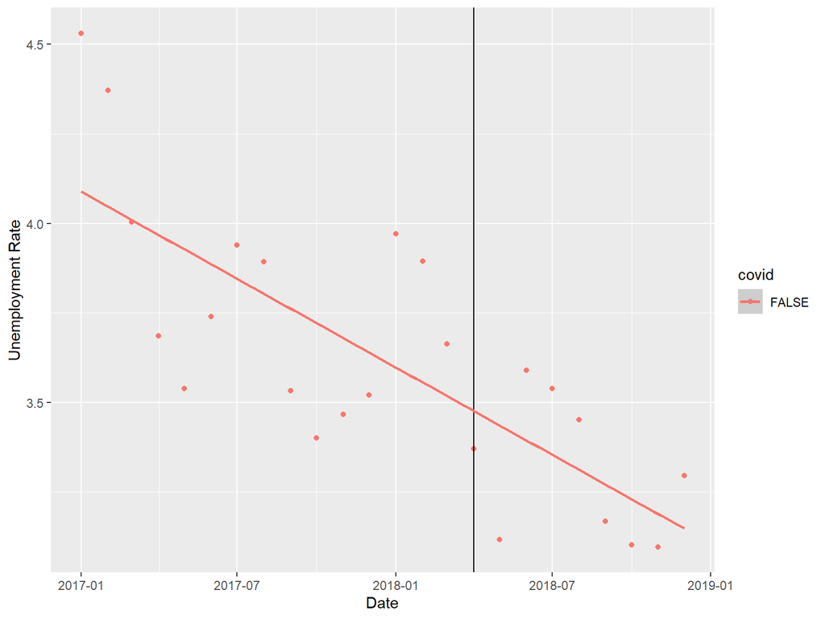

# Graph of Unemployment Rate and Date for 2019 and 2020 Across all Industries:

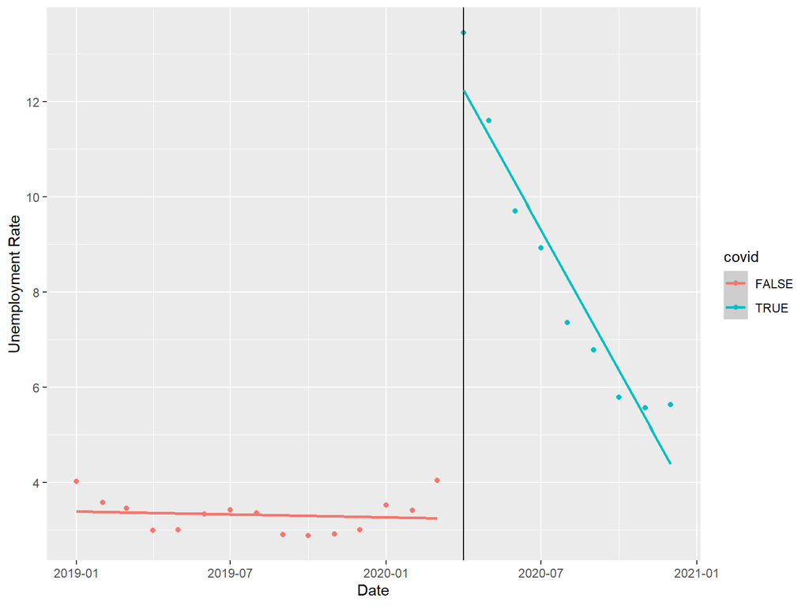

# How has retail fared relative to other industries?

# Linear Model Controlling for Region

```r
model1_part2 <- lm(urate ~ date_centered*covid + covid*indname + region, data = data_part6)
export_summs(model1_part2)
```

|  | Model 1 |
| --- | --- |
| (Intercept) | 3.24 *** |
|  | (0.00) |
| date_centered | -0.01 *** |
|  | (0.00) |
| covidTRUE | 9.03 *** |
|  | (0.00) |
| indnameAgriculture, Forestry, Fishing, and Hunting, and Mining | 0.00 |
|  | (0.00) |
| indnameArts, Entertainment, and Recreation, and Accommodation and Food Services | -0.00 |
|  | (0.00) |
| indnameConstruction | -0.00 |
|  | (0.00) |
| indnameEducational Services, and Health Care and Social Assistance | 0.00 |
|  | (0.00) |
| indnameFinance and Insurance, and Real Estate and Rental and Leasing | 0.00 |
|  | (0.00) |
| indnameInformation | 0.01 |
|  | (0.00) |
| indnameManufacturing | 0.00 |
|  | (0.00) |
| indnameOther Services, Except Public Administration | 0.00 |
|  | (0.00) |
| indnameProfessional, Scientific, and Management, and Administrative and Waste Management Services | -0.00 |
|  | (0.00) |
| indnamePublic Administration | 0.00 |
|  | (0.00) |
| indnameTransportation and Warehousing, and Utilities | -0.00 |
|  | (0.00) |
| indnameWholesale Trade | 0.00 |
|  | (0.00) |
| regionEastNorthCentralDivision | -0.01 *** |
|  | (0.00) |
| regionEastSouthCentralDivision | 0.00 |
|  | (0.00) |
| regionMiddleAtlanticDivision | -0.01 *** |
|  | (0.00) |
| regionMountainDivision | -0.01 ** |
|  | (0.00) |
| regionNewEnglandDivision | -0.01 *** |
|  | (0.00) |
| regionSouthAtlanticDivision | 0.00 |
|  | (0.00) |
| regionWestNorthCentralDivision | -0.00 * |
|  | (0.00) |
| regionWestSouthCentralDivision | 0.00 * |
|  | (0.00) |
| date_centered:covidTRUE | -0.97 *** |
|  | (0.00) |
| covidTRUE:indnameAgriculture, Forestry, Fishing, and Hunting, and Mining | -0.01 |
|  | (0.01) |
| covidTRUE:indnameArts, Entertainment, and Recreation, and Accommodation and Food Services | -0.02 *** |
|  | (0.00) |
| covidTRUE:indnameConstruction | -0.02 *** |
|  | (0.00) |
| covidTRUE:indnameEducational Services, and Health Care and Social Assistance | -0.01 * |
|  | (0.00) |
| covidTRUE:indnameFinance and Insurance, and Real Estate and Rental and Leasing | -0.02 *** |
|  | (0.00) |
| covidTRUE:indnameInformation | -0.01 |
|  | (0.01) |
| covidTRUE:indnameManufacturing | -0.00 |
|  | (0.00) |
| covidTRUE:indnameOther Services, Except Public Administration | -0.02 ** |
|  | (0.01) |
| covidTRUE:indnameProfessional, Scientific, and Management, and Administrative and Waste Management Services | -0.01 *** |
|  | (0.00) |
| covidTRUE:indnamePublic Administration | -0.02 *** |
|  | (0.01) |
| covidTRUE:indnameTransportation and Warehousing, and Utilities | -0.00 |
|  | (0.01) |
| covidTRUE:indnameWholesale Trade | -0.01 |
|  | (0.01) |
| N | 1329400 |
| R2 | 0.96 |
| *** p < 0.001; ** p < 0.01; * p < 0.05. |  |

# Polynomial Model Controlling for Region

```r
model2_part2 <- lm(urate ~ date_centered*covid + I(date_centered^2)*covid + covid*indname + region, data = data_part6)
export_summs(model2_part2)
```

|  | Model 1 |
| --- | --- |
| (Intercept) | 4.02 *** |
|  | (0.00) |
| date_centered | 0.26 *** |
|  | (0.00) |
| covidTRUE | 9.42 *** |
|  | (0.00) |
| I(date_centered^2) | 0.02 *** |
|  | (0.00) |
| indnameAgriculture, Forestry, Fishing, and Hunting, and Mining | 0.00 |
|  | (0.00) |
| indnameArts, Entertainment, and Recreation, and Accommodation and Food Services | 0.00 *** |
|  | (0.00) |
| indnameConstruction | 0.00 * |
|  | (0.00) |
| indnameEducational Services, and Health Care and Social Assistance | -0.00 * |
|  | (0.00) |
| indnameFinance and Insurance, and Real Estate and Rental and Leasing | 0.00 |
|  | (0.00) |
| indnameInformation | 0.00 |
|  | (0.00) |
| indnameManufacturing | 0.00 |
|  | (0.00) |
| indnameOther Services, Except Public Administration | 0.00 |
|  | (0.00) |
| indnameProfessional, Scientific, and Management, and Administrative and Waste Management Services | 0.00 |
|  | (0.00) |
| indnamePublic Administration | 0.00 |
|  | (0.00) |
| indnameTransportation and Warehousing, and Utilities | -0.00 |
|  | (0.00) |
| indnameWholesale Trade | -0.00 |
|  | (0.00) |
| regionEastNorthCentralDivision | 0.00 |
|  | (0.00) |
| regionEastSouthCentralDivision | 0.00 |
|  | (0.00) |
| regionMiddleAtlanticDivision | 0.00 |
|  | (0.00) |
| regionMountainDivision | 0.00 * |
|  | (0.00) |
| regionNewEnglandDivision | 0.00 * |
|  | (0.00) |
| regionSouthAtlanticDivision | -0.00 |
|  | (0.00) |
| regionWestNorthCentralDivision | 0.00 ** |
|  | (0.00) |
| regionWestSouthCentralDivision | -0.00 |
|  | (0.00) |
| date_centered:covidTRUE | -2.26 *** |
|  | (0.00) |
| covidTRUE:I(date_centered^2) | 0.11 *** |
|  | (0.00) |
| covidTRUE:indnameAgriculture, Forestry, Fishing, and Hunting, and Mining | -0.00 |
|  | (0.00) |
| covidTRUE:indnameArts, Entertainment, and Recreation, and Accommodation and Food Services | -0.00 |
|  | (0.00) |
| covidTRUE:indnameConstruction | -0.00 |
|  | (0.00) |
| covidTRUE:indnameEducational Services, and Health Care and Social Assistance | 0.00 |
|  | (0.00) |
| covidTRUE:indnameFinance and Insurance, and Real Estate and Rental and Leasing | -0.00 |
|  | (0.00) |
| covidTRUE:indnameInformation | -0.00 |
|  | (0.00) |
| covidTRUE:indnameManufacturing | -0.00 |
|  | (0.00) |
| covidTRUE:indnameOther Services, Except Public Administration | -0.00 |
|  | (0.00) |
| covidTRUE:indnameProfessional, Scientific, and Management, and Administrative and Waste Management Services | -0.00 |
|  | (0.00) |
| covidTRUE:indnamePublic Administration | -0.00 |
|  | (0.00) |
| covidTRUE:indnameTransportation and Warehousing, and Utilities | 0.00 |
|  | (0.00) |
| covidTRUE:indnameWholesale Trade | 0.00 |
|  | (0.00) |
| N | 1329400 |
| R2 | 0.99 |
| *** p < 0.001; ** p < 0.01; * p < 0.05. |  |

# What has changed about who is working and earning money?

# Employment Changes by Region

```r
model1_part3 <- lm(urate ~ date_centered*covid + covid*region, data = data_part6)
export_summs(model1_part3)
```

|  | Model 1 |
| --- | --- |
| (Intercept) | 3.24 *** |
|  | (0.00) |
| date_centered | -0.01 *** |
|  | (0.00) |
| covidTRUE | 9.02 *** |
|  | (0.00) |
| regionEastNorthCentralDivision | -0.00 * |
|  | (0.00) |
| regionEastSouthCentralDivision | -0.01 * |
|  | (0.00) |
| regionMiddleAtlanticDivision | -0.00 * |
|  | (0.00) |
| regionMountainDivision | -0.00 |
|  | (0.00) |
| regionNewEnglandDivision | -0.00 |
|  | (0.00) |
| regionSouthAtlanticDivision | -0.00 |
|  | (0.00) |
| regionWestNorthCentralDivision | -0.00 |
|  | (0.00) |
| regionWestSouthCentralDivision | -0.00 |
|  | (0.00) |
| date_centered:covidTRUE | -0.97 *** |
|  | (0.00) |
| covidTRUE:regionEastNorthCentralDivision | -0.01 |
|  | (0.00) |
| covidTRUE:regionEastSouthCentralDivision | 0.02 *** |
|  | (0.00) |
| covidTRUE:regionMiddleAtlanticDivision | -0.00 |
|  | (0.00) |
| covidTRUE:regionMountainDivision | -0.00 |
|  | (0.00) |
| covidTRUE:regionNewEnglandDivision | -0.02 *** |
|  | (0.00) |
| covidTRUE:regionSouthAtlanticDivision | 0.01 *** |
|  | (0.00) |
| covidTRUE:regionWestNorthCentralDivision | -0.00 |
|  | (0.00) |
| covidTRUE:regionWestSouthCentralDivision | 0.02 *** |
|  | (0.00) |
| N | 1329400 |
| R2 | 0.96 |
| *** p < 0.001; ** p < 0.01; * p < 0.05. |  |

# Employment Changes by Education Level

- As for education, we saw similar results for after covid. The only statistically significant change was a -.02 lower increase in the unemployment rate for people with PHDs.

```r
model2_part3 <- lm(urate ~ date_centered*covid + region + covid*education, data = data_part6)
export_summs(model2_part3)
```

|  | Model 1 |
| --- | --- |
| (Intercept) | 3.23 *** |
|  | (0.00) |
| date_centered | -0.01 *** |
|  | (0.00) |
| covidTRUE | 9.02 *** |
|  | (0.00) |
| regionEastNorthCentralDivision | -0.01 *** |
|  | (0.00) |
| regionEastSouthCentralDivision | 0.00 |
|  | (0.00) |
| regionMiddleAtlanticDivision | -0.01 ** |
|  | (0.00) |
| regionMountainDivision | -0.01 ** |
|  | (0.00) |
| regionNewEnglandDivision | -0.01 *** |
|  | (0.00) |
| regionSouthAtlanticDivision | 0.00 |
|  | (0.00) |
| regionWestNorthCentralDivision | -0.00 * |
|  | (0.00) |
| regionWestSouthCentralDivision | 0.00 * |
|  | (0.00) |
| educationAssocDegreeAcademic | 0.00 |
|  | (0.00) |
| educationAssocDegreeOCC | 0.00 |
|  | (0.00) |
| educationbachelors | 0.00 ** |
|  | (0.00) |
| educationmasters | 0.01 ** |
|  | (0.00) |
| educationnohighschooldegree | -0.00 |
|  | (0.00) |
| educationphd | 0.00 |
|  | (0.00) |
| educationsomecollegenodegree | 0.00 |
|  | (0.00) |
| date_centered:covidTRUE | -0.97 *** |
|  | (0.00) |
| covidTRUE:educationAssocDegreeAcademic | 0.00 |
|  | (0.00) |
| covidTRUE:educationAssocDegreeOCC | 0.01 |
|  | (0.00) |
| covidTRUE:educationbachelors | 0.00 |
|  | (0.00) |
| covidTRUE:educationmasters | -0.00 |
|  | (0.00) |
| covidTRUE:educationnohighschooldegree | 0.01 |
|  | (0.00) |
| covidTRUE:educationphd | -0.02 ** |
|  | (0.01) |
| covidTRUE:educationsomecollegenodegree | 0.00 |
|  | (0.00) |
| N | 1307124 |
| R2 | 0.96 |
| *** p < 0.001; ** p < 0.01; * p < 0.05. |  |

# Employment Changes by Family Income Level

- As for income, we saw similar results after covid. The only statistically significant change was a .01 lower increase in the unemployment rate for high earners.

```r
model3_part3 <- lm(urate ~ date_centered*covid + region + covid*familyincome, data = data_part6)
export_summs(model3_part3)
```

|  | Model 1 |
| --- | --- |
| (Intercept) | 3.23 *** |
|  | (0.00) |
| date_centered | -0.01 *** |
|  | (0.00) |
| covidTRUE | 9.02 *** |
|  | (0.00) |
| regionEastNorthCentralDivision | -0.01 ** |
|  | (0.00) |
| regionEastSouthCentralDivision | 0.00 |
|  | (0.00) |
| regionMiddleAtlanticDivision | -0.01 ** |
|  | (0.00) |
| regionMountainDivision | -0.00 |
|  | (0.00) |
| regionNewEnglandDivision | -0.01 *** |
|  | (0.00) |
| regionSouthAtlanticDivision | 0.00 |
|  | (0.00) |
| regionWestNorthCentralDivision | -0.00 * |
|  | (0.00) |
| regionWestSouthCentralDivision | 0.00 * |
|  | (0.00) |
| familyincomehighearner | 0.00 * |
|  | (0.00) |
| date_centered:covidTRUE | -0.97 *** |
|  | (0.00) |
| covidTRUE:familyincomehighearner | -0.01 *** |
|  | (0.00) |
| N | 1178650 |
| R2 | 0.96 |
| *** p < 0.001; ** p < 0.01; * p < 0.05. |  |